# *The Bachelor*: Image Processing and Analytics

Cusworth, Heal, Leinicke, Rodriguez.

We obtain (scrape) photos of most contestants from Seasons 13-19 of *The Bachelor*. We register (align) the grayscale images, crop them to a small region containing only the face and face-framing hair, then perform PCA on those cropped images. We then examine the contestants' varying levels of success as represented by the projection of the images onto the first two principal components. We see that in this PC-1&2 space, the 'winners' and 'runners up' classes can be separated by a linear classifier.

Due to the high dimensionality of this data set, we would give this notebook about **2 hours** to run.

# 1. Scrape Data

```python
%matplotlib inline
import numpy as np
import scipy as sp
import matplotlib as mpl
import matplotlib.cm as cm
import matplotlib.pyplot as plt
import pandas as pd
import time
pd.set_option('display.width', 500)
pd.set_option('display.max_columns', 100)
pd.set_option('display.notebook_repr_html', True)
import seaborn as sns
sns.set_style("whitegrid")
sns.set_context("poster")

from pyquery import PyQuery as pq
from bs4 import BeautifulSoup
import requests
```

This 'sirlinksalot' seemed like a really promising place to find photos. It pointed us in the direction of other good sites too!

```python
linkVec = []
for thisPage in [3]:#[2,3,4,5]:
    allLinkPage=requests.get("http://www.sirlinksalot.net/archives/thebachelor%d.html" % (thisPage))
    soup = BeautifulSoup(allLinkPage.text, "html.parser")
    rows = soup.find_all("a")
    for row in rows:
        rowString = str(row)
        checkASCII = [ord(letter) for letter in rowString]
        if max(checkASCII)<127 and min(checkASCII)>9:
            thisLink = str(row.get("href"))
            if "sirlinksalot" not in thisLink: #remove internal links
                if "clickbank.net" not in thisLink: #remove ad links
                    if "pub43" not in thisLink: #remove ad links
                        if "bilbo" not in thisLink: #remove ad links
                            if "fastclick" not in thisLink: #remove ad links
                                if "casalemedia" not in thisLink: #remove ad links
                                    linkVec.append(thisLink)
```

```python
print len(linkVec)
```

```
1753
```

```python
#sort our vector to group similar website roots
linkVec = sorted(linkVec[0:20])
```

```python
archivedLinkVec = []
count = 0;
length = len(linkVec)
for thisLink in linkVec:
    allLinkPage=requests.get("https://web.archive.org/web/*/" + thisLink)
    soup = BeautifulSoup(allLinkPage.text, "html.parser")
    if soup.find_all("div", attrs={"class": "date captures"}):
        row = soup.find_all("div", attrs={"class": "date captures"})[0]
        row = row.find("a").get("href")
        archivedLinkVec.append(str("https://web.archive.org" + row))
    count = count+1
    #print count, " out of ", length, " done"
```

```python
#we can assume that each article from the Examiner website will have similar HTML formatting.
#So let us also note the root page.
rootPage = []
for link in archivedLinkVec:
    first = 50#link.find("www")
    last = link.find(".com")+4
    rootPage.append(link[first:last])
```

```python
#collect into a data frame
linkDF = pd.DataFrame()
linkDF['archived_link']=archivedLinkVec
linkDF['root_page']= rootPage
```

```python
myGroups = linkDF.groupby('root_page')
```

```python
count=0
for group in linkDF.root_page.unique():
    if group:
        count = count+1
print linkDF.root_page.unique()
print "There are",count, "unique groups." #this shows that the number of unique websites
                                          #whose formatting we need to learn is pretty limited.
```

```
['blog.zap2it.com' 'insidetv.ew.com' '' 'www.digitalspy.com'
 'www.eonline.com' 'www.examiner.com' 'www.people.com' 'www.usmagazine.com']
There are 7 unique groups.
```

```python
#SEASON 13 BLUE BACKGROUND
season13Names =[]
season13PicLinks=[]
season13Link = "http://www.buddytv.com/slideshows/meet-the-cast-of-the-bachelor-season-13.aspx"
testPage=requests.get(season13Link)
soup = BeautifulSoup(testPage.text, "html.parser")
scripts = soup.find_all("script")
for script in scripts:
    if script.string:
        if "Slideshow.SlideshowNavigator" in str(script.string):
            mystring = str(script.string)
            myvec = mystring.split("{")
            myvec = myvec[7:32]
            for k in myvec:
                fromhere = str(k).find("Title")+8
                tohere = str(k).find("Blurb")-3
                season13Names.append(k[fromhere:tohere])
                fromhere = str(k).find("ImageId")+9
                tohere = str(k).find("PhotoCredit")-2
                season13PicLinks.append("http://images.buddytv.com/btv_2_%d_1_590_-1_0_/meet-the-cast-of--th.jpg" % int(k[fromhere:tohere]))
len(season13Names), len(season13PicLinks)
```

```
(25, 25)
```

```python
#### SEASON 14 BLUE BACKGROUND
season14Link = "http://www.realitytea.com/2009/12/17/meet-the-25-bachelorettes-of-the-bachelor-14-on-the-wings-of-love-photos/"
season14PicLinks = []
season14Names = []
testPage=requests.get(season14Link)
soup = BeautifulSoup(testPage.text, "html.parser")
rows = soup.find_all("img")
for row in rows:
    if row.get("src"):
        if "the-bachelor-14" in row.get("src"):
            season14PicLinks.append(str(row.get("src")))
            myname = str(row.get("alt"))
            myname = myname.split("14 ")[1]
            season14Names.append(myname)
len(season14Names),len(season14PicLinks)
#season14Names = ["Alexa Mcallister","Ali Fedotowsky","Ashleigh Hunt","Ashley Almore","Caitlyn McCabe","Channy Choch","Christina McCasland","Corrie","Elizabeth Kitt","Elizabeth Kreft","Ella Nolan","Emily Harkins","Gia Alliemand","Jessie Sulidis","Kathryn","Kimberly","Kirsten","Michelle Kujawa","Rozlyn Papa","Sheila","Stephanie","Tenley","Tiana","Valishia Savage","Vienna Girardi"]
```

```
(26, 26)
```

```python
#SEASON 15 BLUE BACKGROUND
season15Link = "http://www.realitytea.com/2010/12/21/photos-meet-the-25-bachelorettes-of-brad-womacks-the-bachelor-15/"
season15PicLinks = []
season15Names=[]
testPage=requests.get(season15Link)
soup = BeautifulSoup(testPage.text, "html.parser")
rows = soup.find_all("img")
for row in rows:
    if row.get("src"):
        if "the-bachelor-15" in row.get("src"):
            season15PicLinks.append(str(row.get("src")))
            season15Names.append(str(row.get("alt")))

len(season15Names),len(season15PicLinks)
```

```
(28, 28)
```

```python
#SEASON 16 BLUE BACKGROUND
season16Link = "http://www.realitytea.com/2011/12/12/photos-%E2%80%93-meet-the-25-bachelorettes-of-ben-flajnik%E2%80%99s-the-bachelor-season-16/"
season16PicLinks = []
season16Names = []
testPage=requests.get(season16Link)
soup = BeautifulSoup(testPage.text, "html.parser")
rows = soup.find_all("img")
for row in rows:
    if row.get("data-lazy-src"):
        if "The_Bachelor_16_" in row.get("data-lazy-src"):
            season16PicLinks.append(str(row.get("data-lazy-src")))
            season16Names.append(str(row.get("alt")))
len(season16Names),len(season16PicLinks)
```

```
(26, 26)
```

```python
#SEASON 17 BLUE BACKGROUND
season17Link = "http://www.realitytea.com/2012/09/28/photos-meet-the-26-bachelorettes-of-sean-lowes-the-bachelor-season-17/"
season17PicLinks = []
season17Names = []
testPage=requests.get(season17Link)
soup = BeautifulSoup(testPage.text, "html.parser")
rows = soup.find_all("img")
for row in rows:
    if row.get("data-lazy-src"):
        if "-sean-lowe-season" in row.get("data-lazy-src"):
            season17PicLinks.append(str(row.get("data-lazy-src")))
            season17Names.append(str(row.get("title")))
len(season17Names),len(season17PicLinks)
```

```
(25, 25)
```

```python
#SEASON 18 BLUE BACKGROUND
season18Links=["http://www.usmagazine.com/entertainment/pictures/the-bachelor-season-18-meet-juan-pablos-bachelorettes-2013412/343%d" % k for k in range(71,98)]
season18PicLinks = []
season18Names = []
for link in season18Links:
    testPage=requests.get(link)
    soup = BeautifulSoup(testPage.text, "html.parser")
    rows = soup.find_all("figure")
    for row in rows:
        if row.get("data-slug"):
            if "18-meet-juan-pablos" in row.get("data-slug"):
                thisimg = row.find_all("img")[0]
                thisimg = thisimg.get("src")
                season18PicLinks.append("http:" + thisimg)
                season18Names.append(str(row.get("data-title")))
len(season18Names),len(season18PicLinks)
```

```
(27, 27)
```

```python
#SEASON 19 BLUE BACKGROUND
season19Links = "http://www.accesshollywood.com/galleries/meet-bachelor-chris-soules-30-farm-girls-in-training-4692"
season19PicLinks = []
season19Names =[]
testPage=requests.get(season19Links)
soup = BeautifulSoup(testPage.text, "html.parser")
rows = soup.find_all("img")
for row in rows:
    if row.get("alt"):
        if "starring Chris Soules" in row.get("alt"):
            season19PicLinks.append(str(row.get("src")))
            b = row.get("alt")
            season19Names.append(b.split()[0])
len(season19Names),len(season19PicLinks)
```

```
(30, 30)
```

```python
#AGGREGATE PICS AND NAMES
allPicLinks = np.concatenate([season13PicLinks,season14PicLinks,season15PicLinks,season16PicLinks,season17PicLinks,season18PicLinks,season19PicLinks])
allNames = np.concatenate([season13Names,season14Names,season15Names,season16Names,season17Names,season18Names,season19Names])

len(allPicLinks),len(allNames)
#might also be helpful: http://www.buddytv.com/tvshow/page/the-bachelor-cast-1.aspx
```

```
(187, 187)
```

# 2. Save links to local machine & Turn into NumPy Arrays

```python
import PIL
from PIL import Image
```

Uncomment this block if running for the first time.

```python
## SAVE ALL PICS TO LOCAL MACHINE
## only really need to do this once
## make sure you're in the right folder on your local machine

# import urllib
# count = 0
# for link in allPicLinks:
#     urllib.urlretrieve(link, "bachelorette_pics/bachelorette%d.jpg" % count)
#     count = count+1
```

Read from the saved file on your local machine.

```python
picsAsMatrices = []
badImages = [5,11,20,25,105]
old_allNames = allNames
print len(old_allNames)
allNames = []
viableIndices = np.concatenate([range(0,5),range(6,11),range(12,20),range(21,25),range(26,105),range(106,187)])
for count in viableIndices:
    picsAsMatrices.append(sp.misc.imread("bachelorette_pics/bachelorette%d.jpg" % count))
    allNames.append(old_allNames[count])
```

```
187
```

```python
picsAsBinaryMatrices = []
#turn pics into B&W, then into (binary) numpy arrays
for count in viableIndices:
    img0 = Image.open("bachelorette_pics/bachelorette%d.jpg" % count).convert('LA')
    img0.save("greyscale_pics/greyscale%d.png" % count)
    img1 = np.array(img0.getdata())
    img2 = (img1[:,1]-img1[:,0]).reshape(img0.size[1], img0.size[0])
    picsAsBinaryMatrices.append(img2)
```

Test code

```python
#plt.imshow(picsAsBinaryMatrices[156]);
#im1 = picsAsBinaryMatrices[15]
#im2 = picsAsBinaryMatrices[16]
#mat1 = np.array(im1.getdata())#.reshape(im1.size[0], im1.size[1], 2)
#mat11= (mat1[:,1]-mat1[:,0]).reshape(im1.size[1], im1.size[0])
#plt.imshow(mat11)

#heights,widths=[],[]
#for pic in picsAsBinaryMatrices:
#    heights.append(pic.size[0])
#    widths.append(pic.size[1])
```

Test code. I tried to use PIL but couldn't get eigenvalues, eigenvectors, etc. with it.

So, I made my own registration package (see next section).

```python
#cropHeight = min(heights)
#cropWidth = min(widths)
#cropParams = [0,0,cropHeight,cropWidth]

#im1 = im1.crop(cropParams)
#im2 = im2.crop(cropParams)
#Image.blend(im1,im2,alpha=0.5)

#newIm = picsAsBinaryMatrices[0]
#newIm = newIm.crop(cropParams)
#for pic in picsAsBinaryMatrices:
#    tempPic = pic.crop(cropParams)
#    newIm = Image.blend(newIm,tempPic,alpha=0.25)

##test
#newIm = np.add(picsAsBinaryMatrices[0],picsAsBinaryMatrices[1])
#newIm = np.add(newIm,picsAsBinaryMatrices[4])
#plt.imshow(newIm)
```

# 3. Registration

```python
#REGISTRATION, using cross-correlation.
from scipy import signal
from scipy import misc
```

Test code

```python
#decRate = 20
#sig0 = [[0,0,0],[0,1,0],[0,0,0]]
#sig1 = picsAsBinaryMatrices[0][85:135,125:175]
#sig2 = picsAsBinaryMatrices[1][80:130,100:150]
#decSig1 = sp.misc.imresize(sig1, decRate, interp='nearest', mode=None)
#decSig2 = sp.misc.imresize(sig2, decRate, interp='nearest', mode=None)
#xcorr = sp.signal.correlate2d(sig0,sig0, mode='full', boundary='symm')

#print xcorr
#print
#print xcorr.shape
#plt.imshow(xcorr);

#plt.imshow(decSig1)

#subset4= picsAsBinaryMatrices[testnum][50:(50+framesize),50:(50+framesize)]
#subset5= picsAsBinaryMatrices[refnum][50:(50+framesize),50:(50+framesize)]
#xcorr = sp.signal.correlate2d(picsAsBinaryMatrices[refnum],subset4, mode='same', boundary='symm')
#print (picsAsBinaryMatrices[refnum]).shape

#decimated = sp.misc.imresize(picsAsBinaryMatrices[0], 10, interp='bilinear', mode=None)
#plt.imshow(decimated)
```

```python
refnum = 6
testnum = 17
framesize = 150
```

```python
#mirror image borders
def mirror_image(im):
    im2 = np.concatenate((im[:,::-1],im),axis=1)
    im2 = np.concatenate((im2,im[:,::-1]),axis=1)
    mirrim = np.concatenate((im2,im2[::-1,:]),axis=0)
    mirrim = np.concatenate((im2[::-1,:],mirrim),axis=0)
    return mirrim
```

```python
#find index of max cross-correlation
#from http://stackoverflow.com/questions/21989513/finding-index-of-maximum-value-in-array-with-numpy
def nanargmax(a):
    idx = np.argmax(a, axis=None)
    multi_idx = np.unravel_index(idx, a.shape)
    if np.isnan(a[multi_idx]):
        nan_count = np.sum(np.isnan(a))
        # In numpy < 1.8 use idx = np.argsort(a, axis=None)[-nan_count-1]
        idx = np.argpartition(a, -nan_count-1, axis=None)[-nan_count-1]
        multi_idx = np.unravel_index(idx, a.shape)
    return multi_idx
```

```python
def crop_pic(im,optpx): #image to align, optimal translation coordinates w.r.t. to some defined reference image

    fsz=0#110 #107 worked with ref 6 and num 4
    #standard image size: (400, 267)
    px = optpx[1]-fsz
    py = optpx[0]-fsz
    x_std = im.shape[1]
    y_std = im.shape[0]
    print x_std+px,x_std*2+px
    print y_std+py,y_std*2+py
    aligned = mirror_image(im)[(y_std-py):(y_std*2-py),(x_std-px):(x_std*2-px)] #y, then x. it's weird I know but yes.
    #crops image to original size about that good part. uses image mirroring.

    return aligned
```

Analysis goal: find eigenvalues & eigenvectors and then do PCA or something.

```python
def crop_to_min_size(im,minsz=(400,267)):

    oldszx,oldszy = im.shape
    newszx,newszy = minsz

    newx0,newy0 = 0,0
    newxf,newyf = minsz
    if oldszx > newszx:
        newx0 = 0
        newxf = newx0 + newszx
    if oldszy > newszy:
        newy0 = (oldszy-newszy)/2
        newyf = newy0 + newszy
    cropped = im[newx0:newxf,newy0:newyf]

    return cropped
```

```python
def crop_pic(im,optpx,fc): #image to align, optimal translation coordinates w.r.t. to some defined reference image

    px = optpx[1]-fc[1]
    py = optpx[0]-fc[0]
    x_std = im.shape[1]
    y_std = im.shape[0]
    aligned = mirror_image(im)[(y_std-py):(y_std*2-py),(x_std+px):(x_std*2+px)] #y, then x. it's weird I know but yes.
    #crops image to original size about that good part. uses image mirroring.

    return aligned
```

```python
def align_to_ref(imn,refn,fsz): #image number, ref number.

    myim = crop_to_min_size(picsAsBinaryMatrices[imn]) #make smallest size so can add all
    refim = picsAsBinaryMatrices[refn]

    fs = framesize; #frame size
    fc = fs/2,np.rint((myim.shape[1])/2) #frame center
    select_face = (fc[0]-fs/2),(fc[0]+fs/2),(fc[1]-fs/2),(fc[1]+fs/2)
    subset= myim[select_face[0]:select_face[1],select_face[2]:select_face[3]]
    xcorr = sp.signal.correlate2d(refim,subset, mode='same', boundary='symm') #takes time
    minx,miny = xcorr.shape

    optpix = nanargmax(xcorr[0:miny/2][0:minx/2]) #best way to translate the picture for alignment
    aligned_image = crop_pic(myim,optpix,fc)

    return aligned_image
```

## All the single ladies (All the single ladies)

Test code.

You can see, by running this block, that we're actually doing something with the cross-correlation; not all of the work was done heuristically in `align_to_ref`. Nice.

```python
#aligned = []
#for i in range(146,149):
#    aligned.append(align_to_ref(i,6,framesize))
#
#fig = plt.figure(figsize=(15,30))
#for a,j,i in zip(aligned,range(1,18),range(146,149)):
#    s=fig.add_subplot(5,4,j)
#    s.imshow(a+crop_to_min_size(picsAsBinaryMatrices[i]))

#meanpic = np.mean([crop_to_min_size(a) for a in aligned], axis = 0)
#plt.imshow(meanpic)
```

# 5. Align and save images to local machine

This took my computer about 29 minutes.

```python
framesize = 200

import time
start = time.time()

alignedSet = []
for thisPic in range(0,len(picsAsBinaryMatrices)):
    #using image 6 as a reference because she is pretty centered in the frame
    alignedSet.append(align_to_ref(thisPic,6,framesize))
    print "Aligning image ", thisPic+1, " out of ", len(picsAsBinaryMatrices)

end = time.time()
print end - start

for thisPic,count in zip(alignedSet,viableIndices):
    np.save("aligned_pics/aligned%d.npy" % count,thisPic) #saved as numpy arrays
```

Retrieve from local machine.

```python
import sys
sys.path.append('Users/Heal/Documents/15FClasses/Data\Science/MR-DC-KH-Final-Project/aligned_pics')
tomat = np.zeros((400,267),dtype=int)

alignedSet = []
for count in viableIndices:
    tomat = np.load("aligned_pics/aligned%d.npy" % count)
    alignedSet.append(tomat)
```

Remove that one, too-small group shot.

```python
alignedSetNew = alignedSet

#find the groupshot
for thisPic,count in zip(alignedSetNew,range(0,len(alignedSetNew))):
    if thisPic.shape[0]<400:
        #delete that groupshot
        alignedSetNew = np.delete(alignedSetNew,count)
        viableIndices = np.delete(viableIndices,count)
        allNames = np.delete(allNames,count)
```

```python
from scipy.signal import decimate

smallSet = []
downsampled = []
for a in alignedSetNew:
    newSmall = a[75:200,75:200]
    smallSet.append(newSmall)
    downsampled.append(decimate(newSmall,10))
print downsampled[0].shape[0]*downsampled[0].shape[1]
print smallSet[0].shape[0]*smallSet[0].shape[1]
```

```
1625
15625
```

We didn't end up downsampling after all. *but we could have!*

# 6. Analysis

This is the average of all the faces. Not too descriptive, since we have so many images and our alignment wasn't perfect.

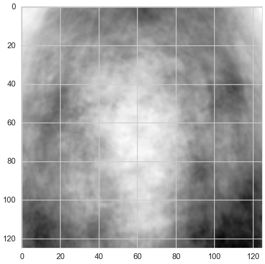

```python
alignedMean = np.mean(smallSet,axis=0); #zoom in on the face
plt.imshow(alignedMean);
```

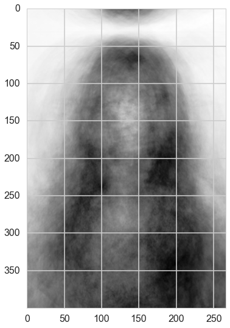

```python
alignedMean = np.mean(alignedSet,axis=0); #overall image
plt.imshow(alignedMean);
```

"Hi, I'm a terrifying demon face" -Average of the matrices

```python
alignedSetNew=smallSet
```

```python
dims = alignedSetNew[0].shape
vecLen = dims[0]*dims[1]
matsAsVects=[]
for im in alignedSetNew:
    matsAsVects.append(np.reshape(im,vecLen))
#now matsAsVects is a vector of 182 of these 106800-vectors.
```

```python
#X = np.concatenate(np.transpose([matsAsVects]),axis=1)
Y = np.transpose(np.concatenate(np.transpose([smallSet])))
X = Y[0,:,:]
```

```python
#Bootstrappin'.
numSamps = X.shape[0]
indboot = np.random.choice(range(0,numSamps),vecLen-numSamps)
Xboot = []
count = 0
for i in indboot:
    Xboot.append(X[i])
    count = count +1
Xboot = np.concatenate([X,Xboot])
Xboot.shape
```

```python
#from Lab 5

# miniblocks =[]
# testsize =10000
# for x in Xboot[0:(testsize^2)]:
#     miniblocks.append(x[0:testsize][0:testsize])

from sklearn.decomposition import PCA
pca = PCA(n_components=10)
```

First principal component of a winner? So we can have a side-by-side comparison.

WHAT THE WHAT this thing took an **hour and a half**!

```python
import time
start = time.time()
Xvec = pca.fit_transform(Xboot)
end = time.time()
print "That took " ,end - start, " seconds."
```

```
That took  5339.78481507  seconds.
```

```python
np.save("pca_copy",pca) #ok let's save this so we never have to run it again
```

```python
pca.components_[0] #should be equal to the mean of the faces
```

```
array([ 0.00395073,  0.00413697,  0.00440736, ...,  0.01104015,
        0.01097309,  0.0105846 ])
```

```python
#from Lab 5
testsize = 15625
def normit(a):
    a=(a - a.min())/(a.max() -a.min())
    a=a*256
    return np.round(a)
def getNC(pc, j):
    size=testsize*testsize
    r=pc.components_[j]#[0:size:3]
    r=normit(r)
    return r
def display_component(pc, j):
    r = getNC(pc,j)
    r = np.array(r)
    myArray = np.zeros((np.sqrt(testsize)), 'uint8')
    myArray = np.transpose(np.reshape(r,(np.sqrt(testsize),np.sqrt(testsize))))
    plt.imshow(myArray)
    plt.xticks([])
    plt.yticks([])
```

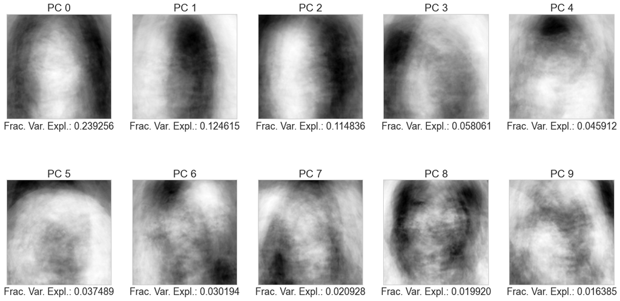

```python
def display_pc(pc, j,ax):
    r = getNC(pc,j)
    r = np.array(r)
    myArray = np.zeros((np.sqrt(testsize)), 'uint8')
    myArray = np.transpose(np.reshape(r,(np.sqrt(testsize),np.sqrt(testsize))))
    ax.imshow(myArray)

#display_component(pca,2)
fig = plt.figure(figsize=(20,10))
count = 0
for r in range(0,10):
    s=fig.add_subplot(2,5,r+1)
    s.set_title("PC %d" % r)
    s.set_xlabel("Frac. Var. Expl.: %f" % pca.explained_variance_ratio_[r] )
    s.set_xticks([])
    s.set_yticks([])
    display_pc(pca,r,s)
```

Approximately 70% of the variance can be explained by these top 10 principal components.

```python
len(Xvec[0:182,i]),len(allNames)
```

```
(182, 182)
```

```python
##season winners
win_ind = [46,52,81,106,129,181]

##first runners up
run_ind = [10,43,50,92,119,140,157]

##eliminated round 1
season13elim = [0,1,2,4,5,13,16,18,19,21]
season14elim = [22,26,27,31,33,37,38,41,42,44]
season15elim = [48,51,53,55,58,59,62,69,70,71]
season16elim = [75,77,82,86,93,99]
season17elim = [103,104,111,113,115,116]
season18elim = [151,149,146,142,135,134,133,130,126]
season19elim = [153,158,160,167,169,172,173,175]

elim_ind = np.concatenate([season13elim,season14elim,season15elim,season16elim,season17elim,season18elim,season19elim])
```

```python
##AFTER the PCA process, we add success labels
winners = np.zeros((len(allNames),)) # 0: all others
winners[win_ind] = [1,1,1,1,1,1] #1: season winners
winners[run_ind] = [.5,.5,.5,.5,.5,.5,.5] #0.5: runners up
winners[elim_ind] = [-1,-1,-1,-1,-1,-1,-1] #-1: elim first week

df = pd.DataFrame({"name":allNames,"winner":winners})
for i in range(pca.explained_variance_ratio_.shape[0]):
    df["pc%i" % (i+1)] = Xvec[0:182,i]
df.head()
```

|  | name | winner | pc1 | pc2 | pc3 | pc4 | pc5 | pc6 | pc7 | pc8 | pc9 | pc10 |
| --- | --- | --- | --- | --- | --- | --- | --- | --- | --- | --- | --- | --- |
| 0 | Ann | -1 | 333.030973 | -832.990257 | -4455.777158 | -2287.666259 | 1165.447774 | -845.679447 | 1589.361471 | 2485.207722 | -699.249813 | -705.050488 |
| 1 | Dominique | -1 | 1836.947700 | -219.211566 | 3661.694986 | 704.234956 | -2565.086450 | -675.603988 | -1743.383590 | 722.510748 | -1728.273023 | -13.924997 |
| 2 | Emily | -1 | -1292.011154 | -1556.000928 | 2182.629186 | -1138.572485 | 436.689851 | 668.198427 | 403.068711 | 115.414179 | 1871.484634 | -675.024079 |
| 3 | Erica | 0 | 1964.096627 | -2548.440160 | -1541.370362 | -1732.080615 | 619.464580 | -793.848366 | 325.231611 | 1436.554222 | 514.411939 | 363.519619 |
| 4 | Jackie | -1 | 818.678733 | 6262.001920 | 2654.231456 | 992.747624 | -341.401627 | 2554.089965 | -403.339241 | 545.354728 | -902.885748 | 577.401197 |

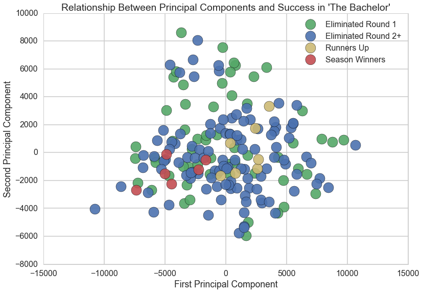

```python
import seaborn as sns
sns.set_style("whitegrid")
sns.set_context("poster")

c0=sns.color_palette()[0]
c1=sns.color_palette()[1]
c2=sns.color_palette()[2]
c3=sns.color_palette()[3]
c4=sns.color_palette()[4]

colors = [c1,c0,c4,c2]
for label, color, transp in zip(df['winner'].unique(), colors,[0.9,0.9,0.9,0.9]):
    mask = df['winner']==label
    plt.scatter(df[mask]['pc1'], df[mask]['pc2'], c=color, label=label,s=400,alpha=transp);
plt.legend(["Eliminated Round 1","Eliminated Round 2+","Runners Up","Season Winners"]);
plt.title("Relationship Between Principal Components and Success in 'The Bachelor'")
plt.xlabel("First Principal Component");
plt.ylabel("Second Principal Component");
```

Whoa! Linearly separable RunnersUp/Winners!

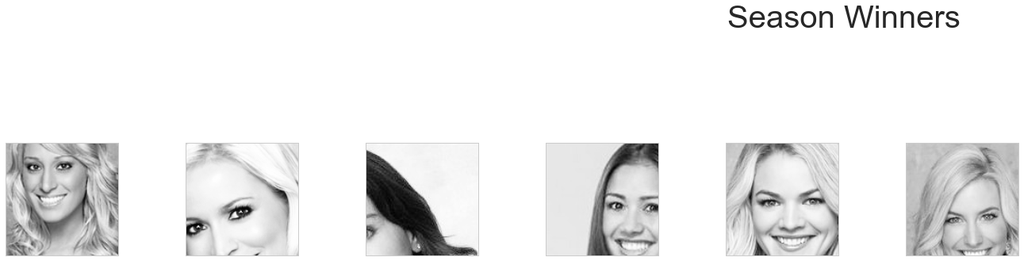

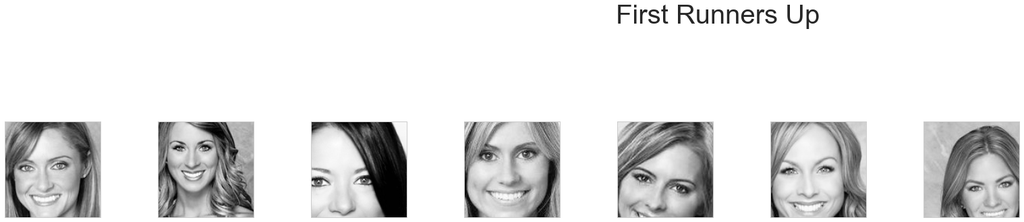

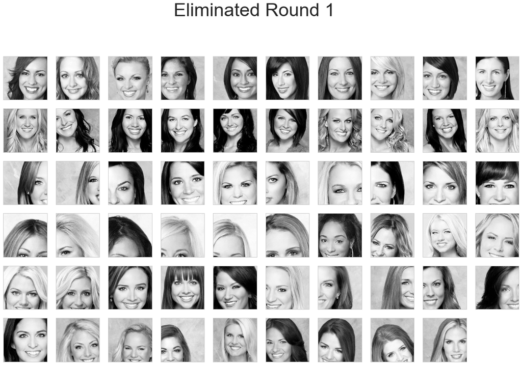

```python
##plot our winners/losers

fig1 = plt.figure(figsize=(40,30))
fig1.suptitle("Season Winners",fontsize=40)
count = 0
for a in win_ind:
    count = count+1
    s=fig1.add_subplot(10,10,count)
    s.imshow(alignedSetNew[int(a)])
    s.set_xticks([])
    s.set_yticks([])

fig2 = plt.figure(figsize=(40,30))
fig2.suptitle("First Runners Up",fontsize=40)
count = 0
for a in run_ind:
    count = count+1
    s=fig2.add_subplot(10,10,count)
    s.imshow(alignedSetNew[int(a)])
    s.set_xticks([])
    s.set_yticks([])

fig3 = plt.figure(figsize=(20,20))
fig3.suptitle("Eliminated Round 1",fontsize=40)
count = 0
for a in elim_ind:
    count = count+1
    s=fig3.add_subplot(10,10,count)
    s.imshow(alignedSetNew[int(a)])
    s.set_xticks([])
    s.set_yticks([])
```

As you can see, the alignment wasn't perfect. Given more time, we could do much better. But, when comparing to the pre-aligned images, the alignment **did** help immensely. In terms of the alignment, given more time we would like to explore rotations and fixed-ratio scaling.

Now we put everything in a nice dictionary so that we can use it with our other analyses.

```python
##just checking stuff
#print [df['name'][j] for j in win_ind]
#[(i, allNames[i]) for i in range(0,len(allNames))]
```

```python
print df.head()
```

```
        name  winner          pc1          pc2          pc3          pc4          pc5          pc6          pc7          pc8          pc9        pc10
0        Ann      -1   333.030973  -832.990257 -4455.777158 -2287.666259  1165.447774  -845.679447  1589.361471  2485.207722  -699.249813 -705.050488
1  Dominique      -1  1836.947700  -219.211566  3661.694986   704.234956 -2565.086450  -675.603988 -1743.383590   722.510748 -1728.273023  -13.924997
2      Emily      -1 -1292.011154 -1556.000928  2182.629186 -1138.572485   436.689851   668.198427   403.068711   115.414179  1871.484634 -675.024079
3      Erica       0  1964.096627 -2548.440160 -1541.370362 -1732.080615   619.464580  -793.848366   325.231611  1436.554222   514.411939  363.519619
4     Jackie      -1   818.678733  6262.001920  2654.231456   992.747624  -341.401627  2554.089965  -403.339241   545.354728  -902.885748  577.401197
```

```python
seasons=[13,14,15,16,17,18,19]
# allDict = pd.DataFrame({"Season":seasons})
# print allDict.head()

##these indices corresp. to the list above, AFTER viableindices has been implemented.
s13=range(0,22)
s14=range(22,47)
s15=range(47,75)
s16=range(75,101)
s17=range(101,125)
s18=range(125,152)
s19=range(152,181)
s = [s13,s14,s15,s16,s17,s18,s19]

seasonDicts=[]
for season,inds in zip(seasons,s):
    seasonNames = [allNames[i] for i in inds]
    seasonPC01 = [(df['pc1'][i],df['pc2'][i]) for i in inds]

    seasonDicts.append( dict(zip(seasonNames,seasonPC01)) )

allDict =  dict(zip(seasons,seasonDicts))
```

```python
import csv

with open('theBachelorPCA_dict.csv','wb') as f:
    w = csv.writer(f)
    w.writerows(allDict.items())
```